# Assessing Accuracy of Variable Selection for Supervised Classification

Dan Carver, Kaitlin Walker, Dane Coats, Megs Seeley, Erika Higa

10 April, 2019

# 1 Implementing Variable Selection Into Random Forest Modeling in Google Earth Engine

This final tutorial will build upon the code created in **Calculating Indices and Extracting Values to Points in Google Earth Engine**. If you did not save that code, simply open the tutorial and copy the final complete code at the end into your GEE code editor.

This section will iterate the random forest modeling process using the variables selected in **Variable Selection Using the rfUtilites Package in R**.

## 1.1 Create New Random Forest Model

First we will create a new set of training data using only the selected variables (green, NIR, and NDVI). We will use the same data collection (PA) to sample the Landsat data and build a classifier.

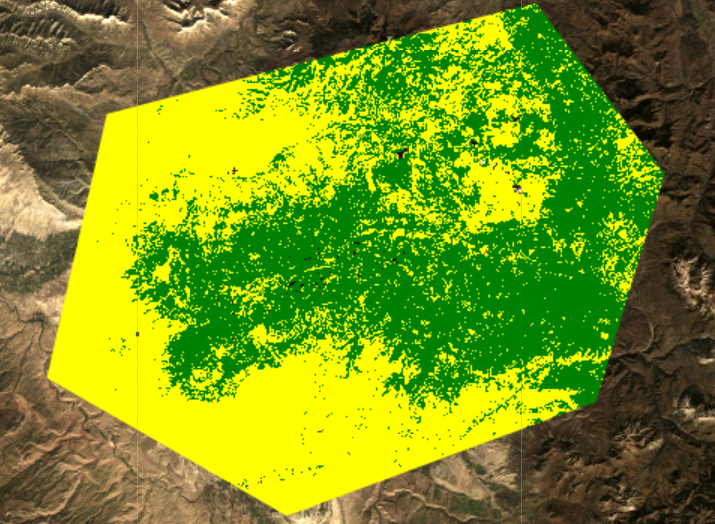

New Model

```javascript
////// | | | Code from Calculating Indices and Extracting Values to Points in Google Earth Engine | | |
//     V V V                  V V V
//In R we identified Green, NIR, and NDVI as our final predictors.
////// | | |                  | | |
//     V V V                  V V V


//Building a new classification

var predictors2 = nir.addBands(green).addBands(ndvi);

//Sample the new image
var samples2 = predictors2.sampleRegions({
  collection: PA,
  properties: ['presence'],
  scale: 30 });
print(samples2,'Updated training dataset');

// Rerun the random forest classification
var trainingClassifier2 = ee.Classifier.randomForest({
  numberOfTrees: 10,
  variablesPerSplit: 0,
  minLeafPopulation: 1 ,
  bagFraction: 0.5 ,
  outOfBagMode: false ,
  seed:7 }).train({
    features: samples2,
    classProperty: 'presence'});

// Classify raster
var classified2 = predictors2.classify(trainingClassifier2).clip(roi);


// Visualize classification
print(classified2, 'Updated Classified Image');
Map.addLayer(classified2, {min:0, max:2, palette:['yellow', 'green', 'blue']}, 'Updated Aspen Classification', false);
```

## 1.2 Compare Models

A quick visual comparison indicates the images from the first and second (reduced predictor set) iterations are similar. To better compare the two classifications, we can subtract the first and second iterations (see code below). Note that this comparison is only visual. We will further assess the accuracy of our new model later.

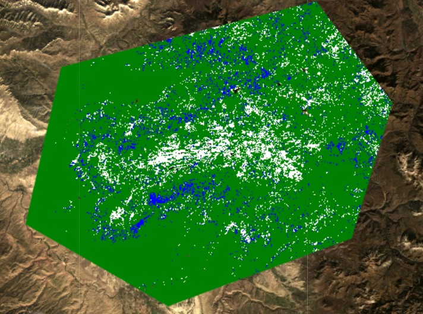

Differences

```javascript
var diffClassified = classified.subtract(classified2);
Map.addLayer(diffClassified, {min:-1, max:1, palette:['white', 'green', 'blue']}, 'Difference between classifications', false);
```

The subtracted image show where the first and second iteration agreed (green) or disagreed. White regions show where the second iteration (with only green, NIR, and NDVI as predictors) classified areas as having aspen and the first did not. Blue shows the inverse. The second iteration of the model classified more aspen in the highlands and less aspen in the foothills.

# 2 Assess Model Accuracy with Confusion Matrices

We know that the model iterations classify our study area differently, but we have not assessed the accuracy of either. To create a confusion matrix, which is a widely-used metric for assessing model accuracy, we must first reserve some of our sampling points to test the data. If we test the model on the same dataset we used to train the data, we will get close to 100% accuracy and learn nothing about our model. Therefore, we will split the data in two.

## 2.1 Split Sample Data

Our methodology for splitting the dataset includes adding a new column populated by a random number from 0 to 1. Since we want a 70/30 split of training/test data, we will include all data with values below 0.7 in the training dataset.

```javascript
// Add column with random value from 0-1
var samplesRandom = samples2.randomColumn('random');

// Split the samples
var split = 0.7;
var trainingSamples = samplesRandom.filter(ee.Filter.lt('random', split)); // Less than 0.7 ~70%
var testSamples = samplesRandom.filter(ee.Filter.gte('random', split)); // Greater/Equal to 0.7 ~30%
print(trainingSamples, 'training');


//Train thrid classifier with training data
var classifier3 = ee.Classifier.randomForest({
  numberOfTrees: 10,
  variablesPerSplit: 0,
  minLeafPopulation: 1 ,
  bagFraction: 0.5 ,
  outOfBagMode: false,
  seed:7 })
  .train({
    features: trainingSamples,
    classProperty: 'presence',
    inputProperties: ['nir', 'green', 'ndvi']});

// Classify the remaining 30% of data with the third classifier
var testClassified = testSamples.classify(classifier3);
```

## 2.2 Create Confusion Matrix

We can now test the accuracy of our model by comparing the modeled outputs to the actual values of our test data by creating a confusion matrix.

```javascript
// Print Confusion and Error Matrices
var errorMatrix = testClassified.errorMatrix('presence', 'classification');
var confusionMatrix = classifier3.confusionMatrix();

print('Test Data Confusion Matrix', errorMatrix);
print('GEE Confusion Matrix: ', confusionMatrix);
print('Overall Accuracy: ', confusionMatrix.accuracy());
```

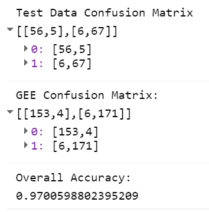

Console with Confusion Matrix

The confusion matrix shows how many of the test points were predicted accurately and how many were inaccurate. Let’s put custom labels on the matrix.

```
                     Absent (Predicted)  | Present (Predicted)
Absent (Actual)   |   True Negative      |    False Positive
Present (Actual)  |   False Negative     |    True Positive
```

# 3 Export the data

Once we are satisfied without model, we will likely want to export the results from GEE. The below code exports our data to Google Drive.

```javascript
// Export the new classified image as a geotiff
Export.image.toDrive({
  image: classified2,
    fileNamePrefix: 'Classified Image',
  description: 'testoutput',
  scale: 30,
  fileFormat: 'GeoTIFF',
  region: roi});
```

FeatureCollections can be exported as: CSV, SHP (shapefile), GeoJSON, KML, KMZ or TFRecord. We will export our points as a csv.

```javascript
Export.table.toDrive({
  collection: samples2,
  description:'PredictorPoints',
  fileNamePrefix: 'Predictor_Points',
  fileFormat: 'CSV'});
```

We will also save these point data as assets we can access from the Google Earth Engine Asset importation menu. To do this, we will give the command an assetId rather than a fileFormat.

```javascript
Export.table.toAsset({
  collection: samples2,
  description:'PredictorPoints_wReflectance',
  assetId: 'Predictor_PointsAssest'});
```

## 3.1 Conclusions

Google Earth Engine is a useful tool for processing and analyzing NASA Earth observation datasets. Cloud computing reduces the processing and downloading time that serves as a barrier to entry into the remote sensing world. Hopefully this series empowers you to integrate NASA Earth observations and Google Earth Engine in your future work.

# 4 Final complete code for lesson

```javascript
////// | | | Code from Calculating Indices and Extracting Values to Points in Google Earth Engine | | |
//     V V V                  V V V
//In R we identified Green, NIR, and NDVI as our final predictors.
////// | | |                  | | |
//     V V V                  V V V


//Building a new classification

var predictors2 = nir.addBands(green).addBands(ndvi);

//Sample the new image
var samples2 = predictors2.sampleRegions({
  collection: PA,
  properties: ['presence'],
  scale: 30 });
print(samples2,'Updated training dataset');

// Rerun the random forest classification
var trainingClassifier2 = ee.Classifier.randomForest({
  numberOfTrees: 10,
  variablesPerSplit: 0,
  minLeafPopulation: 1 ,
  bagFraction: 0.5 ,
  outOfBagMode: false ,
  seed:7 }).train({
    features: samples2,
    classProperty: 'presence'});

// Classify raster
var classified2 = predictors2.classify(trainingClassifier2).clip(roi);


// Visualize classification
print(classified2, 'Updated Classified Image');
Map.addLayer(classified2, {min:0, max:2, palette:['yellow', 'green', 'blue']}, 'Updated Aspen Classification', false);

var diffClassified = classified.subtract(classified2);
Map.addLayer(diffClassified, {min:-1, max:1, palette:['white', 'green', 'blue']}, 'Difference between classifications', false);

// Add column with random value from 0-1
var samplesRandom = samples2.randomColumn('random');

// Split the samples
var split = 0.7;
var trainingSamples = samplesRandom.filter(ee.Filter.lt('random', split)); // Less than 0.7 ~70%
var testSamples = samplesRandom.filter(ee.Filter.gte('random', split)); // Greater/Equal to 0.7 ~30%
print(trainingSamples, 'training');


//Train thrid classifier with training data
var classifier3 = ee.Classifier.randomForest({
  numberOfTrees: 10,
  variablesPerSplit: 0,
  minLeafPopulation: 1 ,
  bagFraction: 0.5 ,
  outOfBagMode: false,
  seed:7 })
  .train({
    features: trainingSamples,
    classProperty: 'presence',
    inputProperties: ['nir', 'green', 'ndvi']});

// Classify the remaining 30% of data with the third classifier
var testClassified = testSamples.classify(classifier3);

// Print Confusion and Error Matrices
var errorMatrix = testClassified.errorMatrix('presence', 'classification');
var confusionMatrix = classifier3.confusionMatrix();

print('Test Data Confusion Matrix', errorMatrix);
print('GEE Confusion Matrix: ', confusionMatrix);
print('Overall Accuracy: ', confusionMatrix.accuracy());

// Export the new classified image as a geotiff
Export.image.toDrive({
  image: classified2,
    fileNamePrefix: 'Classified Image',
  description: 'testoutput',
  scale: 30,
  fileFormat: 'GeoTIFF',
  region: roi});

Export.table.toDrive({
  collection: samples2,
  description:'PredictorPoints',
  fileNamePrefix: 'Predictor_Points',
  fileFormat: 'CSV'});

Export.table.toAsset({
  collection: samples2,
  description:'PredictorPoints_wReflectance',
  assetId: 'Predictor_PointsAssest'});
```